# HotPot

## 火锅团购数据分析

#### 作者：周嘉楠 19210980081

#### 日期：2020年4月10日

```python
# 导入所需第三方库
import numpy as np
import pandas as pd
from sklearn.preprocessing import MinMaxScaler
from sklearn.preprocessing import StandardScaler
from sklearn.impute import SimpleImputer
from sklearn.preprocessing import LabelEncoder
from sklearn.preprocessing import OrdinalEncoder
from sklearn.preprocessing import OneHotEncoder
import seaborn as sns
import matplotlib.pyplot as plt
from pyecharts import options as opts
from pyecharts.charts import Bar
%matplotlib inline
plt.rcParams['font.sans-serif']=['SimHei']

# 导入数据
data = pd.read_csv('HotPot.csv',index_col=0)
# 查看数据集概述
data.info()
```

```
<class 'pandas.core.frame.DataFrame'>
Int64Index: 2688 entries, 1 to 999
Data columns (total 26 columns):
字段1                              2688 non-null object
字段2                              2688 non-null object
discount                         2688 non-null float64
price                            2688 non-null float64
privilege.for.new                2688 non-null object
privilege.on.sale                2688 non-null object
district                         2688 non-null object
if.nonworkdays.available         2688 non-null object
time.duration                    2688 non-null float64
if.appointment.needed            2688 non-null object
WiFi.available                   2688 non-null object
parking                          2688 non-null object
rooms.available                  2688 non-null object
评分                               2688 non-null float64
评论数                              2688 non-null int64
online.intervel                  2688 non-null int64
quarterly.sales.volume           2688 non-null float64
level.of.participants.limited    2688 non-null object
level.of.tickets.limited         2688 non-null object
place                            2688 non-null object
food                             2688 non-null object
taste                            2688 non-null object
cook                             2688 non-null object
people                           2688 non-null object
style                            2688 non-null object
HighFreq                         2688 non-null int64
dtypes: float64(5), int64(3), object(18)
memory usage: 567.0+ KB
```

```python
# 更改类名
data.columns = ["商家店名","广告栏关键词","团购折扣力度","套餐售价","是否钱包新客优惠","是否立减优惠","所属行政区",
                "是否节假日通用","营业时长","是否需预约","是否提供WIFI","停车位","包间","评分","评论数","在线天数",
                "季均销量","每张团购券使用人数限制","每次消费团购张数限制","是否包含地名","是否包含食材","是否包含口味",
                "是否包含烹饪方式","是否包含人物","菜系","使用TOP20高频词的个数"]
data.index.name = None
```

### 2.1 将团购的季均销量转换为对数

```python
# 将团购的季均销量转换为对数(保留3位小数)，为了避免数值0变换为负无穷，故在每个数值前加1再转换
data["季均销量"] = np.round(np.log(data["季均销量"] + 1),decimals=3)
data["季均销量"][:10]
```

```
1       1.859
10      7.536
100     6.148
1000    1.176
1001    2.007
1002    0.110
1003    2.324
1004    2.211
1005    1.588
1006    3.099
Name: 季均销量, dtype: float64
```

### 2.2 对季均销量、团购上线天数、折扣力度绘制分布直方图

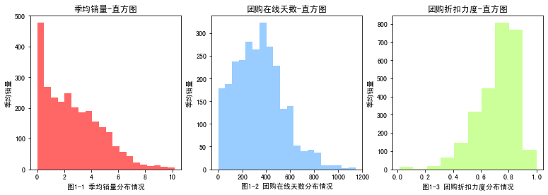

```python
# 绘制直方图
plt.figure(figsize=(13, 4))
plt.subplot(131)
plt.hist(data["季均销量"],bins=20,color='#FF6666')
plt.title("季均销量-直方图",fontsize='large')
plt.xlabel('图1-1 季均销量分布情况',fontsize='medium')
plt.ylabel('季均销量',fontsize='medium')

plt.subplot(132)
plt.hist(data["在线天数"],bins=20,color='#99CCFF')
plt.title("团购在线天数-直方图",fontsize='large')
plt.xlabel('图1-2 团购在线天数分布情况',fontsize='medium')
plt.ylabel('季均销量',fontsize='medium')

plt.subplot(133)
plt.hist(data["团购折扣力度"],bins=10,color='#CCFF99')
plt.title("团购折扣力度-直方图",fontsize='large')
plt.xlabel('图1-3 团购折扣力度分布情况',fontsize='medium')
plt.ylabel('季均销量',fontsize='medium')

plt.show()
```

1. 图1-1是季均销量分布情况，可以看到季均销量（对数形式）分布在0-0.5区间的柱体最高，意味着接近500种团购产品销量不佳， 在0.5~6区间内，销量逐渐减少，此区间内在2.5处的柱体较高，意味着销量较好的产品中，月均销量12币是比较常见的。
2. 图1-2是团购在线天数分布情况，绝大部分在线天数为400天左右，意味着商家产品基本都是在线一年时间，齐次为在线250天、500天左右， 即3个季度、5个季度时长也是比较常见的。
3. 图1-3是团购折扣力度分布情况，可见绝大部分产品折扣力度在7~8折之间，齐次为8~9折，可见折扣力度并不算大。

### 3. 统计火锅团购商家店名高频词，并绘制出词云

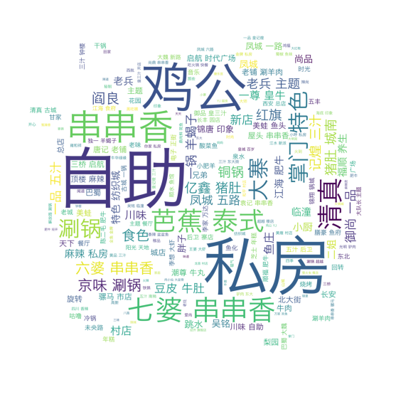

```python
# 导入词云制作库wordcloud和中文分词库jieba
import re
import jieba
import wordcloud
import collections
# 导入imageio库中的imread函数，并用这个函数读取本地图片，作为词云形状图片
import imageio

mk = imageio.imread("hotpot.jpg")
# 设置字体路径
font_path="/System/Library/fonts/Hiragino Sans GB.ttc"
# 构建并配置词云对象w，注意要加stopwords集合参数，将不想展示在词云中的词放在stopwords集合里，这里去掉“曹操”和“孔明”两个词
w = wordcloud.WordCloud(width=1000,
                        height=700,
                        background_color='white',
                        font_path=font_path,
                        mask=mk,
                        scale=15,
                        stopwords={'区','路','重庆','北京','火锅','小','小火锅',
                                   '焖','煲','涮','串串','小区','分店','路店','店','老','锅',
                                   '门店','火锅店','成都'})

# 提取文本
myword = list(data["商家店名"])
myword = " ".join(myword)

# 文本预处理
# 定义正则表达式匹配模式
pattern = re.compile(u'\t|\n|\.|-|:|;|\)|\(|\?|"')
# 将符合模式的字符去除
string_data = re.sub(pattern, '',myword)

# 对文本进行中文分词，得到string
txtlist = jieba.lcut(myword)
string = " ".join(txtlist)

# 原始数据处理（定义需要去掉的词汇与字符）
object_list = []
remove_words = ['区','路','重庆','北京','火锅','小','小火锅','焖','煲','涮','串串','小区','分店','路店',
                '店','老','锅','(',')',' '] # 自定义去除词库

for word in txtlist: # 循环读出每个分词
    if word not in remove_words: # 如果不在去除词库中
        object_list.append(word) # 分词追加到列表

# 词频统计
# 对分词做词频统计
word_counts = collections.Counter(object_list)
# 获取前10最高频的词
word_counts_top10 = word_counts.most_common(10)
word_counts_top10_list = []
for i in range(10):
    word_counts_top10_list.append(word_counts_top10[i][0])

# 将string变量传入w的generate()方法，给词云输入文字
w.generate(string)
# 画出词云图
plt.figure(figsize=(15, 10))
#plt.subplot(121)
plt.imshow(w)
plt.axis('off')
plt.show()

# 将词云图片导出到当前文件夹
# w.to_file('wc_hotpot.jpg')
```

在以上词云图中可以清晰看到商家店名中最常见的词语包括："自助"、"私房"、"鸡公煲"、"串串香"、"清真"、"芭蕉"、"泰式" 等等，说明消费者比较偏好于"自助"、"私房"这两大主题的火锅店，反映了中国食客偏好大食量、有特色的火锅店。 从口味来讲，"鸡公煲"、"串串香"、"芭蕉/泰式"是受消费者偏爱的，意味着除了传统中华美食之外，泰国菜近年来也深受 中国食客的热爱。

### 4.1 箱线图：套餐售价vs团购销量

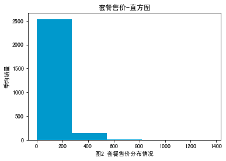

```python
# 查看团购售价的分布情况，看到大部分价格分布在0~200，250~500之间
plt.figure(figsize=(13, 4))
plt.subplot(121)
plt.hist(data["套餐售价"],bins=5,color='#0099CC')
plt.title("套餐售价-直方图",fontsize='large')
plt.xlabel('图2 套餐售价分布情况',fontsize='medium')
plt.ylabel('季均销量',fontsize='medium')
```

从团购产品套餐售价可以看到，90%的产品都在250元以下，所以对价格分类时，主要对在250元以下的价格分组， 如：50元以下，50~100元，100~200元，200~300元，300元以上，总计分为5个价格区间。

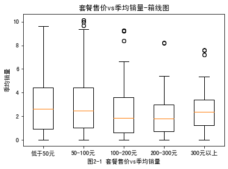

```python
# 设定5个价格区间
price1_index = np.where((0<= data['套餐售价']) & (data['套餐售价'] < 50))
price2_index = np.where((50<= data['套餐售价']) & (data['套餐售价'] < 100))
price3_index = np.where((100<= data['套餐售价']) & (data['套餐售价'] < 200))
price4_index = np.where((200<= data['套餐售价']) & (data['套餐售价'] < 300))
price5_index = np.where(300<= data['套餐售价'])

# 对季均销量进行索引
sales1 = np.array(data['季均销量'])[price1_index]
sales2 = np.array(data['季均销量'])[price2_index]
sales3 = np.array(data['季均销量'])[price3_index]
sales4 = np.array(data['季均销量'])[price4_index]
sales5 = np.array(data['季均销量'])[price5_index]

# 画出箱线图
plt.figure(figsize=(13, 4))
plt.subplot(121)
labels = ['低于50元','50-100元','100-200元','200-300元','300元以上']
plt.boxplot([sales1,sales2,sales3,sales4,sales5],labels=labels)
plt.title("套餐售价vs季均销量-箱线图",fontsize='large')
plt.xlabel('图2-1 套餐售价vs季均销量',fontsize='medium')
plt.ylabel('季均销量',fontsize='medium')
```

图2展示了套餐售价与季均销量的箱线图，低于50元的产品销量中位数最高，后面依次为：50-100元、300元以上、200-300元、 100-200元。可见价格是影响销售量的主要因素，消费者比较偏好100元以下的产品，但是在高于100元的部分中，300元以上的产品 销售量要高于中等价格的产品，可以看出中国餐饮行业有消费升级的趋势。要么属于日常型消费，要么属于改善生活型消费，中间类型的 消费已经不被大众偏爱。

### 4.2 箱线图：周末法定节假日通用vs团购销量

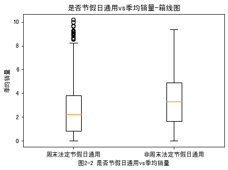

```python
# 将"节假日通用"特征转换为0-1型哑变量
mydict = {'周末法定节假日通用':1, '非周末法定节假日通用':0}
myava = data['是否节假日通用'].map(mydict)
available = np.where(myava == 1)
not_available = np.where(myava == 0)

# 对季均销量进行索引
ava_sales1 = np.array(data['季均销量'])[available]
ava_sales2 = np.array(data['季均销量'])[not_available]

# 画出箱线图
plt.figure(figsize=(13, 4))
plt.subplot(121)
labels = ['周末法定节假日通用','非周末法定节假日通用']
plt.boxplot([ava_sales1,ava_sales2],labels=labels)
plt.title("是否节假日通用vs季均销量-箱线图",fontsize='large')
plt.xlabel('图2-2 是否节假日通用vs季均销量',fontsize='medium')
plt.ylabel('季均销量',fontsize='medium')
```

图2-2展示了是否节假日通用与季均销量之间的关系，可以看到非周末法定节假日通用产品的销量中位数比周末法定节假日通用产品的 中位数要高，说明非周末法定节假日通用的产品可能在价格以及其他优惠上比所有日期通用的产品要好，所以销量更高。

### 4.3 箱线图：店名词汇vs团购销量

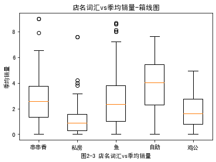

```python
# 先把词频排名前5的词汇取出，在店名一列获取索引，再到销量一列进行索引，得到5个销量的array
shop_names = np.array(data["商家店名"],dtype='<U20')
name_sales_data = []
for i in word_counts_top10_list[:5]:
    name_index = np.flatnonzero(np.core.defchararray.find(shop_names,i)!=-1)
    name_sales = np.array(data['季均销量'])[name_index]
    name_sales_data.append(name_sales)

# 画出箱线图
plt.figure(figsize=(13, 4))
plt.subplot(121)
plt.boxplot([x for x in name_sales_data],labels=[l for l in word_counts_top10_list[:5]])
plt.title("店名词汇vs季均销量-箱线图",fontsize='large')
plt.xlabel('图2-3 店名词汇vs季均销量',fontsize='medium')
plt.ylabel('季均销量',fontsize='medium')
```

图2-3展示了店名包含的词汇与季均销量之间的关系，可以看到包含"自助"关键字的店名销量中位数是明显高于其他字段的，包含 "串串香"、"鱼"这两个字段的店名销量并列排名第二，而包含"私房"字段的店名销量则是最低的。可见消费者最偏好去自助型火锅 进行消费，最喜欢的口味则是"串串香"型火锅，而"私房"是销量最低的原因应该是价格偏高。

### 5. 建立线性回归模型（y=季均销量)

#### 5.1 数据描述与数据预处理

```python
# 数据处理
# 定量变量
quant_var1 = ['套餐售价','团购折扣力度','营业时长','评分','评论数','在线天数']
# 定量变量：店名信息
quant_var2 = ["使用TOP20高频词的个数"]
# 定量变量汇总
quant_vars = ['套餐售价','团购折扣力度','营业时长','评分','评论数','在线天数',"使用TOP20高频词的个数"]
print('定量变量共有:',len(quant_vars),'个')

# 定性变量(两个水平)
quali_var1 = ['是否钱包新客优惠','是否立减优惠','是否节假日通用','是否需预约','每次消费团购张数限制','是否提供WIFI']
# 定性变量(两个水平)汇总
quali_vars1= ['是否钱包新客优惠','是否立减优惠','是否节假日通用','是否需预约','每次消费团购张数限制','是否提供WIFI',
              "是否包含地名","是否包含食材","是否包含口味","是否包含烹饪方式","是否包含人物"]
print('定性变量(两个水平)共有:',len(quali_vars1),'个')

# 定性变量(多个水平)
quali_var2 = ['所属行政区','每张团购券使用人数限制','停车位','包间']
# 定性变量(多个水平)汇总
quali_vars2= ['所属行政区','每张团购券使用人数限制','停车位','包间',"菜系"]
print('定性变量(多个水平)共有:',len(quali_vars2),'个')

# 定性变量：店名信息
quali_var3 = ["是否包含地名","是否包含食材","是否包含口味","是否包含烹饪方式","是否包含人物","菜系"]
print('定量变量(店名信息)共有:',1,'个(使用TOP20高频词的个数)')
print('定性变量(店名信息)(两个水平)共有:',len(quali_var3),'个')
print('定性变量(店名信息)(多个水平)共有:',1,'个(菜系)')
```

```
定量变量共有: 7 个
定性变量(两个水平)共有: 11 个
定性变量(多个水平)共有: 5 个
定量变量(店名信息)共有: 1 个(使用TOP20高频词的个数)
定性变量(店名信息)(两个水平)共有: 6 个
定性变量(店名信息)(多个水平)共有: 1 个(菜系)
```

```python
data_ = data.copy()

# 对定量变量做归一化处理
data_[quant_vars] = MinMaxScaler().fit_transform(data_[quant_vars])

# 定性变量(两个水平）做0-1标签化处理
# 定义一个空字典，放入分类后的情况
quali_dict = {}
def str2num(col_name):
    le = LabelEncoder()
    le = le.fit(col_name)
    value_dict = {}
    for num,value in enumerate(list(le.classes_), start = 0):    # enumerate:返回索引、值
        value_dict[value] = num
    return value_dict

# 对每个2值分类变量进行处理
for i in quali_vars1:
    quali_dict[i] = str2num(data_[i])
    le = LabelEncoder()
    le = le.fit(data_[i])
    data_[i] = le.fit_transform(data_[i])

# 查看分类后的情况
print('定性变量(两个水平)分类后情况：')
quali_dict
```

```
定性变量(两个水平)分类后情况：
```

```
{'是否钱包新客优惠': {'无钱包新客优惠': 0, '钱包新客最高再减20元': 1},
 '是否立减优惠': {'无立减优惠': 0, '有立减优惠': 1},
 '是否节假日通用': {'周末法定节假日通用': 0, '非周末法定节假日通用': 1},
 '是否需预约': {'无需预约': 0, '需预约': 1},
 '每次消费团购张数限制': {'不限张数': 0, '限制张数': 1},
 '是否提供WIFI': {'免费WiFi': 0, '未提及': 1},
 '是否包含地名': {'否': 0, '是': 1},
 '是否包含食材': {'否': 0, '是': 1},
 '是否包含口味': {'否': 0, '是': 1},
 '是否包含烹饪方式': {'否': 0, '是': 1},
 '是否包含人物': {'否': 0, '是': 1}}
```

```python
# 定性变量(多个水平）做哑变量处理
dummy1 = pd.get_dummies(data_[quali_vars2])
dummy2 = pd.get_dummies(data_[quali_vars2],drop_first=True)

mynewcol = []
for i in list(dummy1.columns):
    if i in list(dummy2.columns):
        pass
    else:
        mynewcol.append(i)

print('定性变量(多个水平)基准组分别为：\n',mynewcol)

# 将处理好的定性变量与原表格拼接，并删去原表格无用列
newdata = pd.concat([data_,dummy2],axis=1)
newdata.drop(quali_vars2,axis=1,inplace=True)
newdata.drop(["商家店名","广告栏关键词"],axis=1,inplace=True)

# 调整表格列顺序
order = [
         # 因变量【1个】
         '季均销量',
         # 定量变量【7个】
         '套餐售价','团购折扣力度','营业时长','评分','评论数','在线天数','使用TOP20高频词的个数',
         # 定性变量（2个水平）【11个】
         '是否钱包新客优惠','是否立减优惠','是否节假日通用','是否需预约','是否提供WIFI','每次消费团购张数限制',
         '是否包含地名','是否包含食材','是否包含口味','是否包含烹饪方式','是否包含人物',
         # 定性变量（多个水平）【共20个】
         # 基准组：'菜系_其他'【3个】
         '菜系_北系','菜系_川系','菜系_粤系',
         # 基准组：'所属行政区_临潼区'【9个】
         '所属行政区_新城区','所属行政区_未央区','所属行政区_灞桥区','所属行政区_碑林区','所属行政区_莲湖区','所属行政区_长安区',
         '所属行政区_阎良区','所属行政区_雁塔区','所属行政区_高新区',
         # 基准组：'每张团购券使用人数限制_不限人数'【3个】
         '每张团购券使用人数限制_限1人','每张团购券使用人数限制_限2-4人','每张团购券使用人数限制_限5-12人',
         # 基准组：'停车位_免费停车位'【3个】
         '停车位_收费停车位','停车位_无停车位','停车位_未提及',
         # 基准组：'包间_仅限大厅使用'【2个】
         '包间_均可使用','包间_未提及']
newdata = newdata[order]
```

```
定性变量(多个水平)基准组分别为：
 ['所属行政区_临潼区', '每张团购券使用人数限制_不限人数', '停车位_免费停车位', '包间_仅限大厅使用', '菜系_其他']
```

#### 5.2 线性回归

```python
# 进行线性回归
# 使用前2000行数据作为训练集
import statsmodels.api as sm
X = newdata[newdata.columns[1:]][:2000]
Y = newdata['季均销量'][:2000]
X = sm.add_constant(X)
est = sm.OLS(Y,X).fit()
est.summary()
```

OLS Regression Results

| Dep. Variable: | 季均销量 | R-squared: | 0.558 |
| --- | --- | --- | --- |
| Model: | OLS | Adj. R-squared: | 0.549 |
| Method: | Least Squares | F-statistic: | 65.10 |
| Date: | Fri, 10 Apr 2020 | Prob (F-statistic): | 1.19e-314 |
| Time: | 20:14:58 | Log-Likelihood: | -3507.1 |
| No. Observations: | 2000 | AIC: | 7092. |
| Df Residuals: | 1961 | BIC: | 7311. |
| Df Model: | 38 |  |  |
| Covariance Type: | nonrobust |  |  |

|  | coef | std err | t | P>\|t\| | [0.025 | 0.975] |
| --- | --- | --- | --- | --- | --- | --- |
| const | 2.6610 | 0.372 | 7.154 | 0.000 | 1.932 | 3.391 |
| 套餐售价 | -1.8023 | 0.586 | -3.076 | 0.002 | -2.951 | -0.653 |
| 团购折扣力度 | -0.0501 | 0.235 | -0.213 | 0.831 | -0.512 | 0.411 |
| 营业时长 | 0.1305 | 0.244 | 0.535 | 0.592 | -0.348 | 0.609 |
| 评分 | 2.5674 | 0.079 | 32.322 | 0.000 | 2.412 | 2.723 |
| 评论数 | 16.2662 | 0.891 | 18.260 | 0.000 | 14.519 | 18.013 |
| 在线天数 | -2.5233 | 0.211 | -11.933 | 0.000 | -2.938 | -2.109 |
| 使用TOP20高频词的个数 | 0.1336 | 0.203 | 0.657 | 0.511 | -0.265 | 0.532 |
| 是否钱包新客优惠 | -1.3276 | 0.241 | -5.518 | 0.000 | -1.799 | -0.856 |
| 是否立减优惠 | 0.1831 | 0.146 | 1.253 | 0.210 | -0.104 | 0.470 |
| 是否节假日通用 | 0.6686 | 0.100 | 6.681 | 0.000 | 0.472 | 0.865 |
| 是否需预约 | -0.3144 | 0.130 | -2.422 | 0.016 | -0.569 | -0.060 |
| 是否提供WIFI | -0.6004 | 0.082 | -7.362 | 0.000 | -0.760 | -0.440 |
| 每次消费团购张数限制 | 0.0763 | 0.092 | 0.825 | 0.410 | -0.105 | 0.258 |
| 是否包含地名 | 0.1554 | 0.103 | 1.511 | 0.131 | -0.046 | 0.357 |
| 是否包含食材 | 0.0740 | 0.075 | 0.988 | 0.324 | -0.073 | 0.221 |
| 是否包含口味 | 0.2828 | 0.087 | 3.238 | 0.001 | 0.112 | 0.454 |
| 是否包含烹饪方式 | -0.1167 | 0.088 | -1.330 | 0.184 | -0.289 | 0.055 |
| 是否包含人物 | 0.2317 | 0.139 | 1.666 | 0.096 | -0.041 | 0.504 |
| 菜系_北系 | -0.3353 | 0.178 | -1.886 | 0.059 | -0.684 | 0.013 |
| 菜系_川系 | -0.3505 | 0.093 | -3.771 | 0.000 | -0.533 | -0.168 |
| 菜系_粤系 | -0.8437 | 0.223 | -3.790 | 0.000 | -1.280 | -0.407 |
| 所属行政区_新城区 | 0.3045 | 0.181 | 1.682 | 0.093 | -0.050 | 0.659 |
| 所属行政区_未央区 | 0.1051 | 0.146 | 0.717 | 0.473 | -0.182 | 0.392 |
| 所属行政区_灞桥区 | 0.0233 | 0.179 | 0.130 | 0.897 | -0.328 | 0.375 |
| 所属行政区_碑林区 | 0.6352 | 0.157 | 4.036 | 0.000 | 0.327 | 0.944 |
| 所属行政区_莲湖区 | 0.3575 | 0.158 | 2.269 | 0.023 | 0.048 | 0.667 |
| 所属行政区_长安区 | 0.2840 | 0.167 | 1.697 | 0.090 | -0.044 | 0.612 |
| 所属行政区_阎良区 | 1.0537 | 0.201 | 5.235 | 0.000 | 0.659 | 1.448 |
| 所属行政区_雁塔区 | 0.4611 | 0.150 | 3.080 | 0.002 | 0.167 | 0.755 |
| 所属行政区_高新区 | 0.2384 | 0.190 | 1.256 | 0.209 | -0.134 | 0.611 |
| 每张团购券使用人数限制_限1人 | 0.4852 | 0.157 | 3.097 | 0.002 | 0.178 | 0.793 |
| 每张团购券使用人数限制_限2-4人 | -0.2182 | 0.087 | -2.501 | 0.012 | -0.389 | -0.047 |
| 每张团购券使用人数限制_限5-12人 | -0.4445 | 0.122 | -3.645 | 0.000 | -0.684 | -0.205 |
| 停车位_收费停车位 | -0.1864 | 0.144 | -1.291 | 0.197 | -0.469 | 0.097 |
| 停车位_无停车位 | -0.1208 | 0.108 | -1.122 | 0.262 | -0.332 | 0.090 |
| 停车位_未提及 | 0.1555 | 0.097 | 1.601 | 0.110 | -0.035 | 0.346 |
| 包间_均可使用 | 0.0308 | 0.088 | 0.348 | 0.728 | -0.143 | 0.204 |
| 包间_未提及 | 0.4093 | 0.150 | 2.723 | 0.007 | 0.115 | 0.704 |

| Omnibus: | 126.403 | Durbin-Watson: | 1.714 |
| --- | --- | --- | --- |
| Prob(Omnibus): | 0.000 | Jarque-Bera (JB): | 347.284 |
| Skew: | 0.326 | Prob(JB): | 3.88e-76 |
| Kurtosis: | 4.934 | Cond. No. | 59.0 |

Warnings:  
[1] Standard Errors assume that the covariance matrix of the errors is correctly specified.

```python
# 利用训练模型进行预测
# 使用后688行数据作为训练集
X_test = newdata[newdata.columns[1:]][2000:]
Y_test = newdata['季均销量'][2000:]
X_test = sm.add_constant(X_test)
Y_hat = est.predict(X_test)

# 计算RMSE
rmse_loss = np.sqrt(np.square(Y_test - Y_hat).mean())
print('rmse_loss:', rmse_loss)
```

```
rmse_loss: 1.5947537396469487
```

### 5.3 模型解读

一、 定量变量

1. 套餐售价、团购折扣力度、在线天数与季均销量成反比：首先价格与销量成反比是正常的经济现象，团购折扣力度越大（即数值越小）则销量越高，而在线天数越长效率越低，意味着越难卖的产品在线天数也就越长。
2. 营业时长. 评分. 评论数. 使用TOP20高频词的个数与季均销量成正比：营业时间越长、评分越高、评论数越多、店名中包含的高频词汇越多，则销量越大，也是容易理解的现象。